# Tutorial, Analise Exploratorios de Dados

Lourdes M.M Villavicencio

8/26/2019

Este tutorial, apresenta uma analise exploratoria dos dados do zika virus, Você encontrara o dataset no site da Kaggel https://www.kaggle.com/cdc/zika-virus-epidemic

Carregamos as librerias necessarias

```r
library(dplyr)
library(data.table)
library(ggplot2)
library(RColorBrewer)
library(rworldmap)
library(tidyr)
```

Carregamos os dados

```r
setwd("~/Milagros/cursosR/cdc_zika.csv")
zika <- read.csv('cdc_zika.csv',stringsAsFactors = F, header = T)
```

```r
class(zika)
```

```
[1] "data.frame"
```

```r
dim(zika)
```

```
[1] 107619      9
```

```r
colnames(zika)
```

```
[1] "report_date"      "location"         "location_type"
[4] "data_field"       "data_field_code"  "time_period"
[7] "time_period_type" "value"            "unit"
```

```r
str(zika)
```

```
'data.frame':   107619 obs. of  9 variables:
 $ report_date     : chr  "2016-03-19" "2016-03-19" "2016-03-19" "2016-03-19" ...
 $ location        : chr  "Argentina-Buenos_Aires" "Argentina-Buenos_Aires" "Argentina-Buenos_Aires" "Argentina-Buenos_Aires" ...
 $ location_type   : chr  "province" "province" "province" "province" ...
 $ data_field      : chr  "cumulative_confirmed_local_cases" "cumulative_probable_local_cases" "cumulative_confirmed_imported_cases" "cumulative_probable_imported_cases" ...
 $ data_field_code : chr  "AR0001" "AR0002" "AR0003" "AR0004" ...
 $ time_period     : logi  NA NA NA NA NA NA ...
 $ time_period_type: logi  NA NA NA NA NA NA ...
 $ value           : chr  "0" "0" "2" "1" ...
 $ unit            : chr  "cases" "cases" "cases" "cases" ...
```

```r
zika <- zika %>%
separate(col = "report_date", into = c("year", "month"), sep = "-") %>%
separate(col = "location", into = c("country", "state"), sep = "-")
```

[output not shown]

```r
zika$value <- as.character(zika$value)
zika$value <- as.numeric(zika$value,na.rm=TRUE)
```

#organizando os meses

```r
zika$month_name <- ""
zika$month_name[which(zika$month == "01")] <- "jan"
zika$month_name[which(zika$month == "02")] <- "fev"
zika$month_name[which(zika$month == "03")] <- "mar"
zika$month_name[which(zika$month == "04")] <- "abr"
zika$month_name[which(zika$month == "05")] <- "mai"
zika$month_name[which(zika$month == "06")] <- "jun"
zika$month_name[which(zika$month == "07")] <- "jul"
zika$month_name[which(zika$month == "11")] <- "nov"
zika$month_name[which(zika$month == "12")] <- "dez"
```

```r
zika$confirmed <- ifelse(grepl('confirmed', zika$data_field), TRUE, FALSE)
zika$mc <- ifelse(grepl('microcephaly', zika$data_field), TRUE, FALSE)
```

Grafico de barras, dos paises com casos confirmados com zika

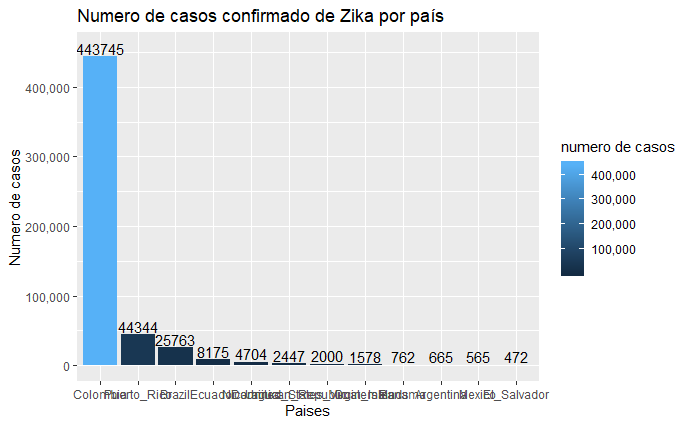

```r
country_data <- zika %>%
filter(confirmed == T & unit == 'cases' & !is.na(value)) %>%
group_by(country) %>%
summarise(num_cases = sum(value,na.rm = T)) %>%
arrange(desc(num_cases))

library(scales)
ggplot(data=country_data,
     aes(x=reorder(country, desc(num_cases)),
           y=num_cases,
           fill=num_cases))+
  geom_bar(stat='identity') +
  geom_text(aes(x = reorder(country, desc(num_cases)),
                y = num_cases, label = num_cases), nudge_y = 12000) +
  labs(x = "Paises",
       y = "Numero de casos",
       title = "Numero de casos confirmado de Zika por país") +
  scale_fill_continuous(name= "numero de casos", labels=comma) +
  scale_y_continuous(labels =  comma)
```

Gráficos de barras, mostrando por mes, as incidencias de Zika nos paises onde houve maior incidencia de Zika no ano de 2016.

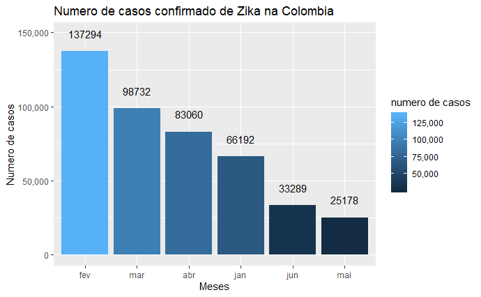

```r
colombia_2016 <- zika %>%
filter(confirmed == T & unit == 'cases' & !is.na(value)) %>%
select(year, month, country, value, month_name) %>%
filter(country == "Colombia") %>%
group_by(month, month_name) %>%
summarise(num_cases = sum(value,na.rm = T)) %>%
arrange(desc(num_cases))

ggplot(data=colombia_2016,
        aes(x=reorder(month_name, desc(num_cases)),
            y=num_cases,
            fill=num_cases))+
   geom_bar(stat='identity') +
   geom_text(aes(x = reorder(month_name, desc(num_cases)),
                 y = num_cases, label = num_cases), nudge_y = 12000) +
   labs(x = "Meses",
        y = "Numero de casos",
        title = "Numero de casos confirmado de Zika na Colombia") +
   scale_fill_continuous(name= "numero de casos", labels=comma) +
   scale_y_continuous(labels =  comma)
```

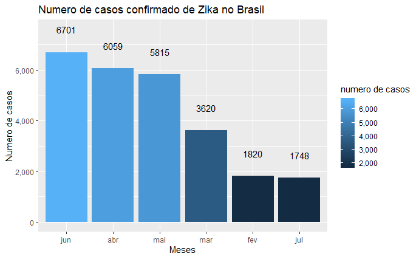

```r
Brasil2016 <- zika %>%
  filter(confirmed == T & unit == 'cases' & !is.na(value)) %>%
  select(year, month, country, value, month_name) %>%
  filter(country == "Brazil") %>%
  group_by(month, month_name) %>%
  summarise(num_cases = sum(value,na.rm = T)) %>%
  arrange(desc(num_cases))

ggplot(data=Brasil2016,
       aes(x=reorder(month_name, desc(num_cases)),
           y=num_cases,
           fill=num_cases))+
  geom_bar(stat='identity') +
  geom_text(aes(x = reorder(month_name, desc(num_cases)),
                y = num_cases, label = num_cases), nudge_y = 900) +
  labs(x = "Meses",
       y = "Numero de casos",
       title = "Numero de casos confirmado de Zika no Brasil") +
  scale_fill_continuous(name= "numero de casos", labels=comma) +
  scale_y_continuous(labels =  comma)
```

Box Plot, para o numero de casos por região no Brasil.

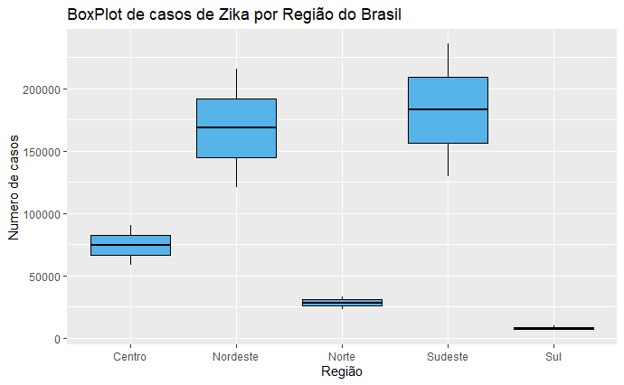

```r
region<- zika%>%
select(country, year, value,month, month_name)%>%
filter(country %in% c("Norte","Nordeste","Sudeste","Sul","Centro"))%>%
group_by(year,month, month_name, country) %>%
summarise(num_cases = sum(value,na.rm  = T)) %>%
arrange(desc(num_cases))

ggplot(region, aes(x=country, y=num_cases)) +
geom_boxplot( colour = "black", fill = "#56B4E9") +
labs(title="BoxPlot de casos de Zika por Região do Brasil",x="Região", y = "Numero de casos")
```

Grafico de barras, mostrando a incidencia total de casos confirmados no brasil por estado e por mes.

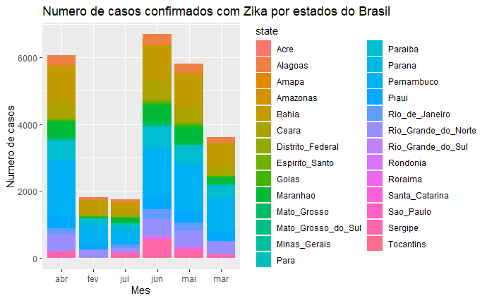

```r
BR_uf <- zika %>%
filter(confirmed == T & unit == 'cases' & !is.na(value)) %>%
select(year, month, month_name,state, country, state, value) %>%
filter(country == "Brazil") %>%
group_by(month_name, month,state) %>%
drop_na(state) %>%
summarise(num_cases = sum(value,na.rm  = T)) %>%
arrange(desc(num_cases))
ggplot(BR_uf ,
       aes(x = month_name, y = num_cases, fill = state)) +
      geom_bar(stat='identity') +
      labs(x = "Mes",
       y = "Numero de casos",
       title = "Numero de casos confirmados com Zika por estados do Brasil")
```

Gráfico de função de densidade de probabilidade, mostra a distribuição de casos de zika.

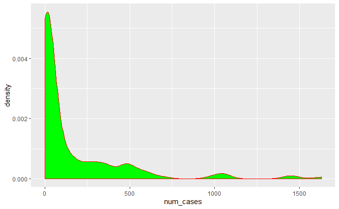

```r
BR_uf %>%
  ggplot(aes(x = num_cases)) +
  geom_density(color = "red", fill = "green")
```

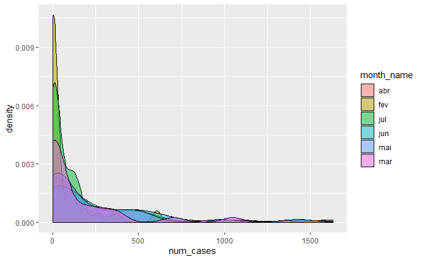

```r
BR_uf %>%
  ggplot(aes(x = num_cases))+
  geom_density(aes(fill = month_name),
               # adicionar transparencia
               alpha = 0.5 )
```

```r
mean_uf <- zika %>%
    select(year, month, country, state, value) %>%
    filter(country == "Brazil") %>%
    group_by(state) %>%
    drop_na(state) %>%
    summarise(avg_state = round(mean(value, na.rm = T), digits = 0)) %>%
    mutate(avg_pop = avg_state/100000)
mean_uf
```

| state | avg_state | avg_pop |
| --- | --- | --- |
| Acre | 40 | 0.00040 |
| Alagoas | 144 | 0.00144 |
| Amapa | 10 | 0.00010 |
| Amazonas | 150 | 0.00150 |
| Bahia | 1709 | 0.01709 |
| Ceara | 114 | 0.00114 |
| Distrito_Federal | 19 | 0.00019 |
| Espirito_Santo | 104 | 0.00104 |
| Goias | 122 | 0.00122 |
| Maranhao | 125 | 0.00125 |

[output cut: 17 more lines]

Apresenta-se uma exemplo simples de um test- t para duas amostras independentes, aqui não levamos em conta a normalidade dos dados. H0: as medias são iguais H1: as medias são deiferentes Se rejeita H0 para um p-valor<0.05

```r
Acre<- zika%>%
select(state, year, value,month, month_name)%>%
filter(state == "Acre" ) %>%
group_by(year,month, month_name, state) %>%
summarise(num_cases = sum(value,na.rm  = T))%>%
arrange(desc(num_cases))

Alagoas<- zika%>%
  select(state, year, value,month, month_name)%>%
  filter(state == "Alagoas" ) %>%
  group_by(year,month, month_name, state) %>%
  summarise(num_cases = sum(value,na.rm  = T))%>%
  arrange(desc(num_cases))
```

```r
dados <- data.frame( resposta = c(Acre$num_cases,Alagoas$num_cases),
  grupos=c(rep("Acre", 6), rep("Alagoas", 6)))
dados
```

| resposta | grupos |
| --- | --- |
| 3602 | Acre |
| 2049 | Acre |
| 198 | Acre |
| 151 | Acre |
| 91 | Acre |
| 51 | Acre |
| 12893 | Alagoas |
| 7455 | Alagoas |
| 1689 | Alagoas |
| 1338 | Alagoas |

[output cut: 2 more lines]

```r
teste_t <- t.test(resposta ~ grupos, data=dados, var.equal=TRUE)
teste_t
```

```
    Two Sample t-test

data:  resposta by grupos
t = -1.4415, df = 10, p-value = 0.18
alternative hypothesis: true difference in means is not equal to 0
95 percent confidence interval:
 -7845.819  1681.819
sample estimates:
   mean in group Acre mean in group Alagoas
             1023.667              4105.667
```